# Intro. to QGIS

## Outline

- Overview: Why QGIS?
- Installing
- Getting data in
  - Background Map (WMS/Quickmap)
  - Shapefile
  - csv & text
  - geoJSON
  - kml
  - Raster
- Saving your map
- Coordinate Systems & Projections

## Overview: Why QGIS?

QGIS is a full featured Open Source GIS package, but why use it over google maps/earth, CartoDB, National Maps or Aperture?

**Pros:**

- Accepts many different formats
- Powerful software that will grow with you
- Free

**Cons:**

- Steep learning curve
- Can be buggy

## Installing

https://qgis.org/

- Download version 2.18
- This is the current (May 2018) long term release repository and most stable (and what I'm using).

*Note: you may need to remove any previous versions if you have installed it before*

## Getting data in: Background

- Install plugin: QuickMapServices
- Select background option
- Search for background option

*OpenLayers is similar plugin that does something similar*

## Getting data in: Shapefile

Shapfile is an ESRI proprietary GIS data format but is has become a bit of an industry standard format.

**Pros:**

- Fast
- Common format
- Multiple geometry types

**Cons:**

- Required multiple files per layer
- Restricted header length

Data:

- VicMap Transport
- https://www.data.vic.gov.au/

## Getting data in: csv & text

Comma separated text files a very common and can be plotted on a map if they contain spatial co-ordinates in the file, e.g. Latitude and Longitude.

**Pros:**

- Very common format
- Can be created and edited with any text editor
- Very robust in terms of longevity

**Cons:**

- Tends to be slower
- Only point geometry
- May need to know about projections
- Can't be used for some geospatial operations processes

Data:

- On-street Car Parking Meters with Location
- https://data.melbourne.vic.gov.au/

## Getting data in: geoJSON

JSON formatted files are very common these days. It is a text format designed to be easy for both humans and computers to read and is often used for web-based data transfer.

**Pros:**

- Common format
- Multiple geometry types
- Human-readable & easily edited

**Cons:**

- Slower than shapefiles
- Larger file size than CSV

Data:

- Greater Shepparton City Council Street and Park Trees
- https://data.gov.au/

## Getting data in: kml

Keyhole markup language is a format that was brought into the public sphere by google. It is an xml format which is another from of human and computer readable text format.

**Pros:**

- Common format
- Multiple geometry types
- Human-readable & easily edited

**Cons:**

- Attribute data is not easy for computers to read
- Larger file size than CSV

Data:

- Hiking gps trace

## Getting data in: Raster

A raster is a bit different to the other data other sources. A raster is a grid of values where the location in the grid give the spatial location (when aligned and scaled correctly).

Rasters are usually image files that can contain data just be an image like an aerial photo, however they can also be text files with a grid format.

Data:

- Georeferenced recreational map

## Saving your map

## Coordinate Systems

There are two main categories of coordinate systems:

**Geographic (dms)**

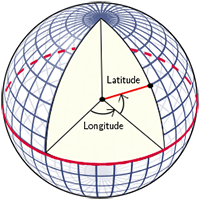

**Projected (x, y)**

- Good for smaller areas
- Measurement units in metres/km/miles
- Printed maps

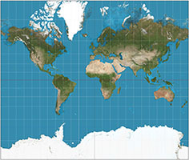

- Try and keep all your data in the same spherical or projected coordinate system!

Credits:

Tebjan Halm - https://vvvv.org/blog/polar-spherical-and-geographic-coordinates  
Strebe - CC BY-SA 3.0, https://commons.wikimedia.org/w/index.php?curid=16115307

## Thanks!

Maps & Graphs - mapsgraphs.blogspot.com